# ASSESSMENT3

2022-04-07

# **ASSESSMENT 3 - BUSINESS REPORT**

## STEPHEN RENALDO SETIADI - S4665076

## RYOSUKE OTSUKA - S4663911

## ——————————————————————————————————

```r
library(tidyverse)
library(knitr)
library(tidymodels)
library(skimr)
library(dplyr)
library(kableExtra)
```

### EXECUTIVE SUMMARY

This report aims to provide a piece of information and recommendation for analysis decisions using the information from the data set. Furthermore, this report seeks to address the business problem of what will be the best-selling ramen in the world based on the data provided and give analytical insight into the output, providing what kind of ramen should be sold by each company to increase sales in the future.

The method used for analysis was using data descriptive exploration analysis to examine any relation and dependencies between variables and to prove any positive relations within the variables in the data set. Ensuring the dataset generates the best quality information is vital to preparing the data adequately.

Major question to predict the output

1. Can we predict the star’s rating on ramen based on the predictor?
2. Can we predict brand based on the predictor?

### INTRODUCTION

Though being recognised as a portion of unhealthy food, ramen is one of the best selling Asian food, which has a variety of flavours, depending on the country where they put the originalities into ramen. However, given the popularity of ramen in the world, many food industries endeavour to releace the new items to exacerbate the competition of ramen industries. The following report looks at the data, which displays the rating stars of each ramen following brand, variety, country, and style information.

### BUSINESS PROBLEM

The data set contains information about ramen reviews around the world. This report will provide information about ramen rating and visualise the data to make readers understand and gain focused details. Not only helpful in gaining knowledge, but the data can help make thoughtful decisions regarding the ramen market worldwide.

This report will explore the prediction of ramen rating and what would also provide information of what would be the best way or methodology to predict the ramen rating using different categorical predictors.

Central Question: Can we predict the stars rating on ramen based on the packaging and its brand? Sub-questions:

Q1. Can we predict the stars’ ramen rating by knowing their brand, country and packing style?

Q2. Can we predict brands by knowing their, stars, country and style?

### ABOUT THE DATA SET

The dataset discovers how four different predictors influence the ramen review in the world. For example, the style and brand of ramen will affect the stars rating of the ramen

**LOAD THE DATA SET**

```r
ramen_ratings_ori <- readr::read_csv("https://raw.githubusercontent.com/rfordatascience/tidytuesday/master/data/2019/2019-06-04/ramen_ratings.csv")
```

### DATA CLEANSING

It is vital of checking our data set before we do the analysis. The cleaning of the data set will increase overall productivity and help produce the best quality information to predict and recommend the best decision to get the best result of the prediction.

**1. Remove any space ” ” between the variable names and replace it with “_“.**

```r
ramen_ratings <- ramen_ratings_ori
```

```r
names(ramen_ratings)<-str_replace(names(ramen_ratings)," ", "_")
```

**2. Detecting and deleting Null Values**

```r
is.na(ramen_ratings) <- ramen_ratings == ''
```

```r
colSums(is.na(ramen_ratings))
```

```
## review_number         brand       variety         style       country
##             1             0             0             2             0
##         stars
##            14
```

```r
which(is.na(ramen_ratings$style))
```

```
## [1] 2753 3043
```

```r
ramen_ratings<-ramen_ratings%>%
  filter(!is.na(stars))%>%
  select(-review_number)
```

Missing values in “Stars” column. Now we will delete this rows in the dataset and removing colum review number from the data set.

**3. Change the “character” variables into a “factor” for better analysis**

```r
ramen_ratings <- ramen_ratings %>%
    mutate_if(is.character, factor)
```

```r
skim(ramen_ratings)
```

Data summary

| Name | ramen_ratings |
| --- | --- |
| Number of rows | 3166 |
| Number of columns | 5 |
| _______________________ |  |
| Column type frequency: |  |
| factor | 4 |
| numeric | 1 |
| ________________________ |  |
| Group variables | None |

**Variable type: factor**

| skim_variable | n_missing | complete_rate | ordered | n_unique | top_counts |
| --- | --- | --- | --- | --- | --- |
| brand | 0 | 1 | FALSE | 454 | Nis: 443, Non: 110, Mar: 106, Myo: 90 |
| variety | 0 | 1 | FALSE | 2958 | Bee: 7, Chi: 7, Mis: 7, Yak: 7 |
| style | 2 | 1 | FALSE | 8 | Pac: 1818, Bow: 612, Cup: 559, Tra: 138 |
| country | 0 | 1 | FALSE | 44 | Jap: 529, Uni: 374, Sou: 355, Tai: 330 |

**Variable type: numeric**

| skim_variable | n_missing | complete_rate | mean | sd | p0 | p25 | p50 | p75 | p100 | hist |
| --- | --- | --- | --- | --- | --- | --- | --- | --- | --- | --- |
| stars | 0 | 1 | 3.69 | 1.03 | 0 | 3.25 | 3.75 | 4.5 | 5 | ▁▁▂▇▅ |

### DESCRIPTIVE OR EXPLORATORY ANALYSIS

To allow us understand the data we will use descriptive analysis to predict the data.

**1. We can see there are 8 different types of ramen style, so the amount of ramen classified under 8 categories**

```r
ramen_ratings%>%
count(style, sort = TRUE, name="Total style")%>%
kable()%>%
kable_styling(bootstrap_options = "striped", full_width = F, position = "left")
```

| style | Total style |
| --- | --- |
| Pack | 1818 |
| Bowl | 612 |
| Cup | 559 |
| Tray | 138 |
| Box | 32 |
| Restaurant | 3 |
| NA | 2 |
| Bar | 1 |
| Can | 1 |

**2. Total of Each Packaging Style, in the following graph describes total of each packaging style.**

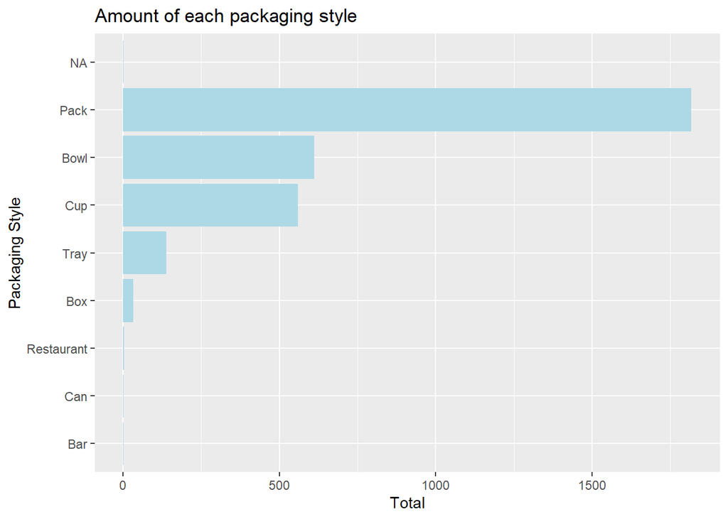

```r
ramen_ratings%>%
  count(style, sort = TRUE, name= "Total_style")%>%
  mutate(style = fct_reorder(style,Total_style))%>%
  ggplot( aes(x=style, y = Total_style))+
  geom_col(position="stack",fill="light blue")+
  coord_flip()+
  labs(title = "Amount of each packaging style", x="Packaging Style",y="Total")
```

As can be seen from the graph, “Pack” packaging style is the most poppular style in the dataset with more than 1500

**3. Top 10 Countries that have the highest number of ramen**

```r
ramen_country <- ramen_ratings %>%
  group_by(country) %>%
  summarise(count = n()) %>%
  arrange(desc(count))%>%
  top_n(n = 10, wt = count)
```

```r
kable(ramen_country)%>%
    kable_styling(bootstrap_options = "striped", full_width = F, position = "left")
```

| country | count |
| --- | --- |
| Japan | 529 |
| United States | 374 |
| South Korea | 355 |
| Taiwan | 330 |
| China | 207 |
| Thailand | 205 |
| Malaysia | 181 |
| Hong Kong | 155 |
| Indonesia | 150 |
| Singapore | 134 |

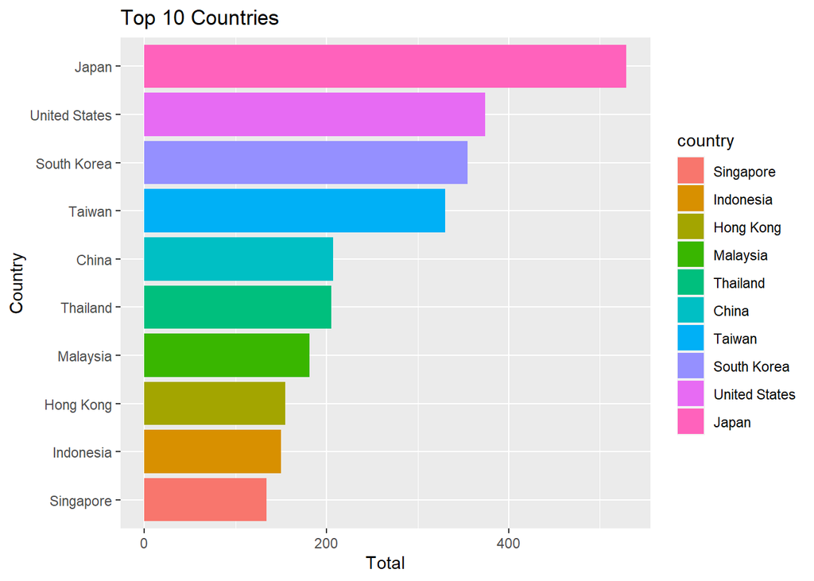

```r
ramen_country%>%
  count(country, count, sort = TRUE)%>%
  mutate(country = fct_reorder(country,count))%>%
  ggplot(aes(country, count, fill = country))+
  geom_col()+
  coord_flip()+
  labs(title = "Top 10 Countries", x="Country",y="Total")
```

From the graph we found that japan has most highest number of ramen in all group rating.

**4. Top 10 brand that have the most amount of ramen**

```r
ramen_brands <- ramen_ratings %>%
  group_by(brand) %>%
  summarise(count = n()) %>%
  arrange(desc(count))%>%
  top_n(n = 10, wt = count)
```

```r
kable(ramen_brands)%>%
    kable_styling(bootstrap_options = "striped", full_width = F, position = "left")
```

| brand | count |
| --- | --- |
| Nissin | 443 |
| Nongshim | 110 |
| Maruchan | 106 |
| Myojo | 90 |
| Samyang Foods | 81 |
| Mama | 71 |
| Paldo | 71 |
| Indomie | 56 |
| Ottogi | 47 |
| Sapporo Ichiban | 44 |

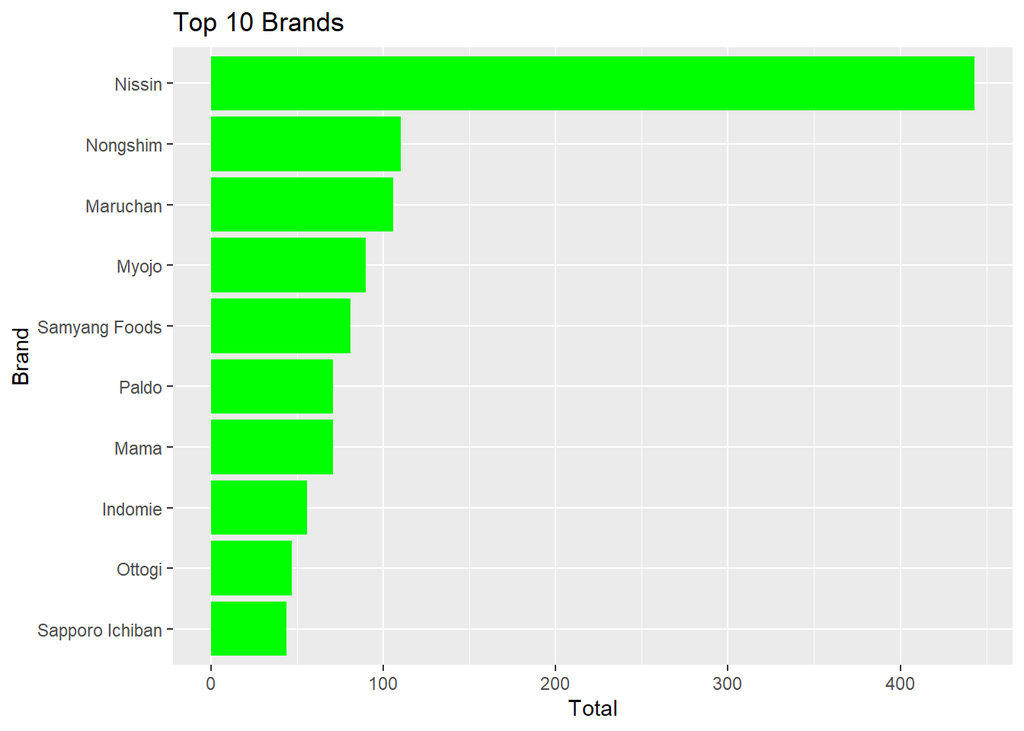

```r
ramen_brands %>%
  count(brand, count, sort = TRUE)%>%
  mutate(brand = fct_reorder(brand,count))%>%
  ggplot(aes(x = brand, y = count, fill=count)) +
  geom_col(fill="green")+
  coord_flip()+
  labs(title = "Top 10 Brands", x="Brand",y="Total")
```

The graph shows nissin is the most higest variety of ramen.

```r
top10_ratings <- ramen_ratings %>%
  group_by(country) %>%
  summarise(count = n()) %>%
  arrange(desc(count))%>%
  top_n(n = 10, wt = count)%>%
  ungroup()
```

```r
kable(top10_ratings)%>%
    kable_styling(bootstrap_options = "striped", full_width = F, position = "left")
```

| country | count |
| --- | --- |
| Japan | 529 |
| United States | 374 |
| South Korea | 355 |
| Taiwan | 330 |
| China | 207 |
| Thailand | 205 |
| Malaysia | 181 |
| Hong Kong | 155 |
| Indonesia | 150 |
| Singapore | 134 |

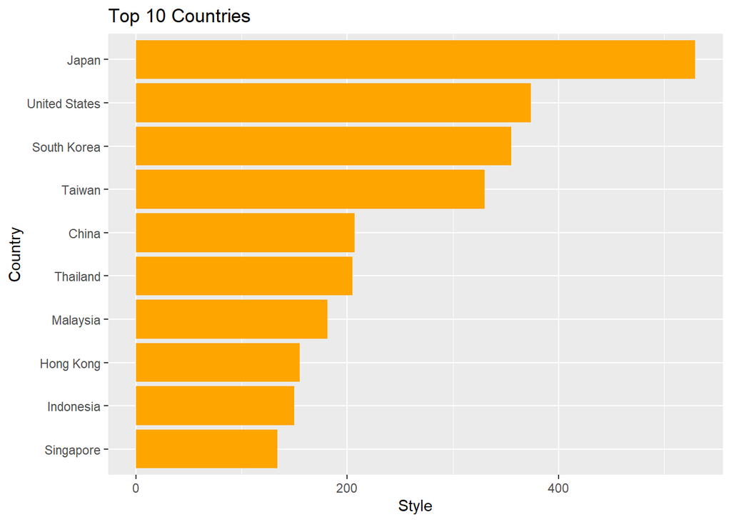

```r
top10_ratings%>%
count(country, count, sort = TRUE)%>%
mutate(country = fct_reorder(country, count))%>%
ggplot(aes(x = country, y = count, fill=count)) + geom_col(fill="orange")+
coord_flip()+
  labs(title = "Top 10 Countries", x="Country",y="Style")
```

**summary of the categorical predictors**

```r
library(broom)
```

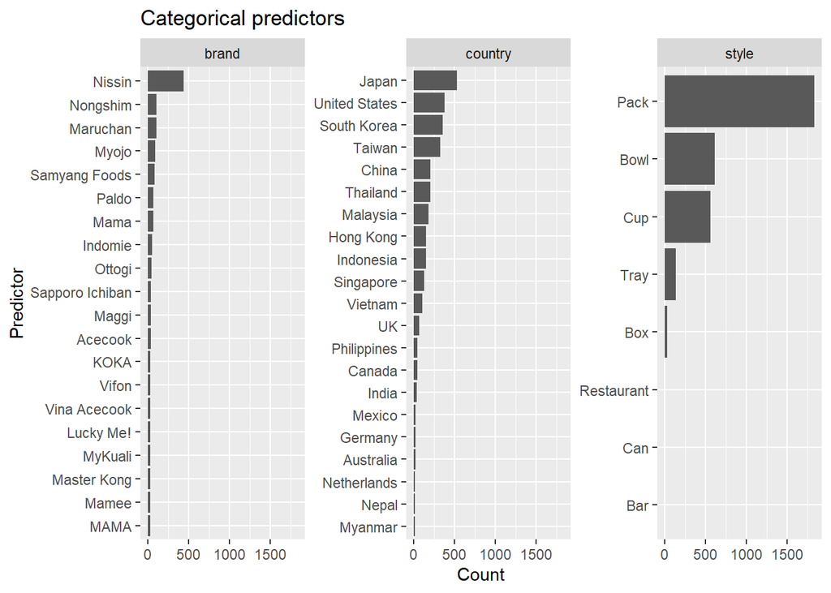

```r
ramen_ratings_ori%>%
  filter(!is.na(style))%>%
  gather(category, value, -variety , - stars, -review_number)%>%
  count(category, value)%>%
  group_by(category)%>%
  top_n(20,n)%>%
  ungroup()%>%
  mutate(value = fct_reorder(value, n))%>%
  ggplot(aes(value,n))+
  geom_col()+
  facet_wrap(~category, scales = "free_y")+
  coord_flip()+
  labs(title = "Categorical predictors", x ="Predictor", y ="Count")+
  theme_set(theme_light())
```